# Analyzing Individual BGG Users

Phil Henrickson

2022-01-02

# **thechampz’s** BoardGameGeek Collection

This notebook contains a set of analyses for the selected user’s boardgamegeek collection. The bulk of the analysis is focused on building a user-specific predictive model to predict the games that thechampz is likely to own. This enables to ask questions like, based on the games the user currently owns, what games are a good fit for their collection? What upcoming games are they likely to purchase?

This analysis is based on data from BoardGameGeek that was last updated on **2021-12-20.**

# 1 Collection Overview

We can look at a basic description of the number of games that the user owns, has rated, has previously owned, etc.

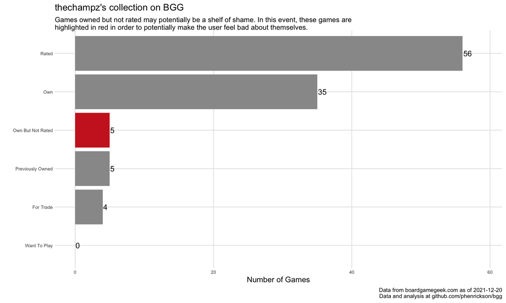

What years has the user owned/rated games from? While we can’t see when a user added or removed a game from their collection, we can look at their collection by the years in which their games were published.

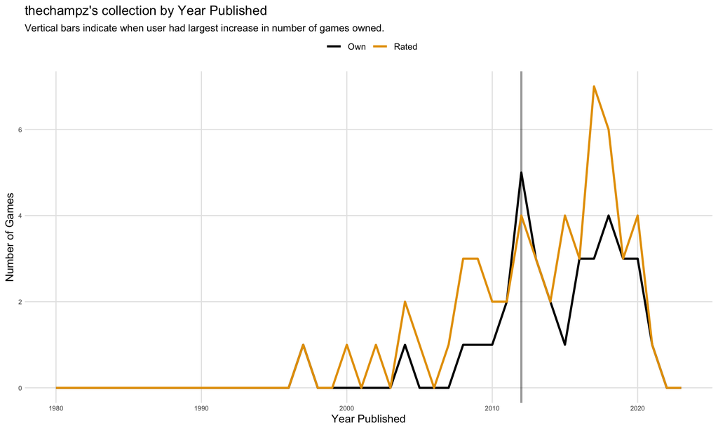

## 1.1 What types of games does thechampz own?

We can look at the most frequent types of categories, mechanics, designers, and artists that appear in a user’s collection.

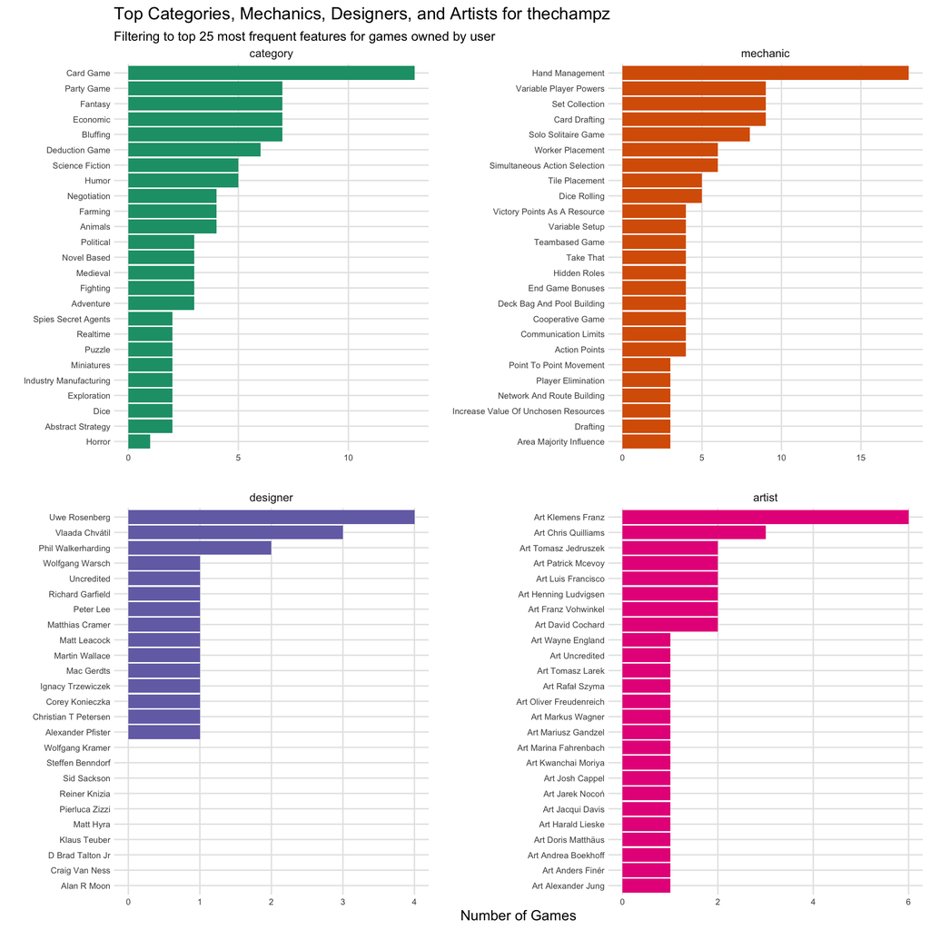

# 2 Modeling **thechampz’s** Collection

| username | dataset | period | games_owned | games_rated | games_played |
| --- | --- | --- | --- | --- | --- |
| thechampz | training | published before 2020 | 30 | 49 | 54 |
| thechampz | test | published 2020 or later | 4 | 5 | 5 |

There are two main (binary) outcomes we will be modeling for the user.

The first, **own** refers to whether the user currently lists a game as owned in their collection. The second, **played** refers to whether the user currently owns, has rated, or previously owned a game. This means the latter will generally have a larger list of games, but may still be a useful category to examine for people who play lots of games without necessarily owning them.

We will train predictive models to learn the probability that the user will own or play individual games based on their features.

## 2.1 Coefficients for thechampz

We can examine coefficients from the trained modes, which are penalized logistic regressions fit to our two main outcomes. Positive values indicate that a feature increases a user’s probabilility of owning/rating a game, while negative values indicate a feature decreases the probability.

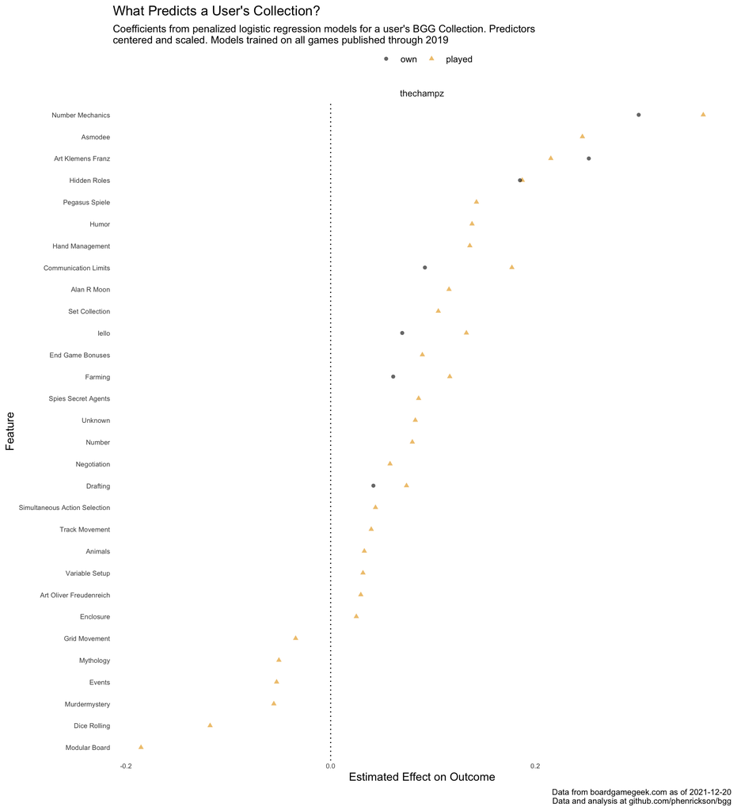

## 2.2 Visualizing Predictors for thechampz’s Collection

Why did the model identify these features? We can make density plots of the important features for predicting whether the user owned a game. Blue indicates the density for games owned by the user, while grey indicates the density for games not owned by the user.

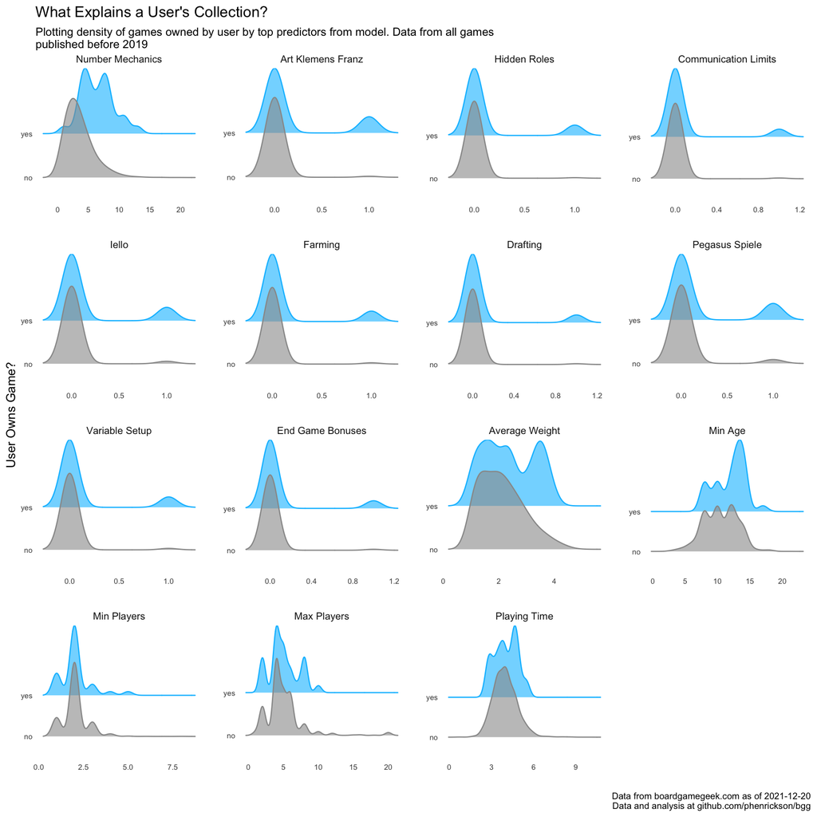

Binary predictors can be difficult to see with this visualization, so we can also directly examine the percentage of games in a user’s collection with a predictor vs the percentage of all games with that predictor.

| username | Feature | % of Games with Feature In_Collection | % of Games with Feature All_Games | Ratio |
| --- | --- | --- | --- | --- |
| thechampz | Hidden Roles | 13.3% | 0.7% | 19.4 |
| thechampz | Communication Limits | 10.0% | 1.0% | 10.3 |
| thechampz | Drafting | 10.0% | 1.0% | 9.7 |
| thechampz | Farming | 13.3% | 1.7% | 8.0 |
| thechampz | End Game Bonuses | 10.0% | 1.3% | 7.9 |
| thechampz | Variable Setup | 13.3% | 1.9% | 7.2 |
| thechampz | Iello | 16.7% | 3.1% | 5.4 |
| thechampz | Pegasus Spiele | 20.0% | 4.7% | 4.2 |
| thechampz | Negotiation | 13.3% | 3.6% | 3.7 |
| thechampz | Deduction Game | 16.7% | 6.4% | 2.6 |
| thechampz | Party Game | 20.0% | 8.4% | 2.4 |
| thechampz | Puzzle | 6.7% | 3.4% | 2.0 |
| thechampz | Word Game | 3.3% | 1.8% | 1.9 |
| thechampz | Medieval | 10.0% | 6.3% | 1.6 |
| thechampz | Horror | 3.3% | 4.0% | 0.8 |
| thechampz | City Building | 3.3% | 4.3% | 0.8 |
| thechampz | Realtime | 3.3% | 4.2% | 0.8 |
| thechampz | Trivia | 0.0% | 1.8% | 0.0 |
| thechampz | Racing | 0.0% | 2.8% | 0.0 |
| thechampz | Action Dexterity | 0.0% | 4.8% | 0.0 |
| thechampz | Mafia | 0.0% | 0.7% | 0.0 |
| thechampz | Trains | 0.0% | 2.2% | 0.0 |
| thechampz | Prehistoric | 0.0% | 1.0% | 0.0 |
| thechampz | Sports | 0.0% | 2.0% | 0.0 |
| thechampz | Murdermystery | 0.0% | 1.8% | 0.0 |

# 3 Assess Model’s Performance on Training Set

Before predicting games in upcoming years, we can examine how well the model did and what games it liked in the training set. In this case, we used resampling techniques (cross validation) to ensure that the model had not seen a game before making its predictions.

## 3.1 Separation Plot

An easy way to examine the performance of classification model is to view a separation plot. We plot the predicted probabilities from the model for every game (from resampling) from lowest to highest. We then overlay a blue line for any game that the user does own. A good classifier is one that is able to *separate* the blue (games owned by the user) from the white (games not owned by the user), with most of the blue occurring at the highest probabilities (right side of the chart).

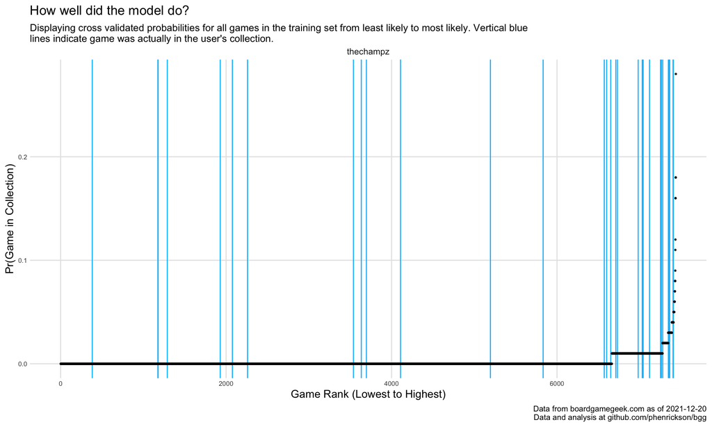

## 3.2 Top Games for **thechampz** from Training Set

We can display this information in table form, displaying the 100 games with the highest probability of ownership, adding a blue line when the user does own the game.

| username | yearpublished | game_id | name | pred_played | pred_own | actual_played | actual_own |
| --- | --- | --- | --- | --- | --- | --- | --- |
| thechampz | 2018 | 244711 | Newton | 0.53 | 0.28 | 0 | 0 |
| thechampz | 2009 | 39683 | At the Gates of Loyang | 0.42 | 0.18 | 0 | 0 |
| thechampz | 2014 | 156129 | Deception: Murder in Hong Kong | 0.42 | 0.18 | 0 | 0 |
| thechampz | 2008 | 37111 | Battlestar Galactica: The Board Game | 0.22 | 0.16 | 0 | 0 |
| thechampz | 2007 | 31260 | Agricola | 0.29 | 0.16 | 1 | 0 |
| thechampz | 2017 | 216132 | Clans of Caledonia | 0.14 | 0.12 | 0 | 0 |
| thechampz | 2014 | 152241 | Ultimate Werewolf | 0.06 | 0.11 | 0 | 0 |
| thechampz | 2013 | 102794 | Caverna: The Cave Farmers | 0.05 | 0.09 | 0 | 0 |
| thechampz | 2015 | 182874 | Grand Austria Hotel | 0.26 | 0.08 | 0 | 0 |
| thechampz | 2000 | 478 | Citadels | 0.60 | 0.08 | 0 | 0 |
| thechampz | 2015 | 178054 | A Study in Emerald (Second Edition) | 0.07 | 0.08 | 0 | 0 |
| thechampz | 2016 | 236217 | Timebomb | 0.11 | 0.07 | 0 | 0 |
| thechampz | 2002 | 3955 | BANG! | 0.03 | 0.07 | 1 | 0 |
| thechampz | 1986 | 925 | Werewolf | 0.09 | 0.07 | 0 | 0 |
| thechampz | 2017 | 227515 | Riverboat | 0.05 | 0.06 | 0 | 0 |
| thechampz | 2018 | 241831 | Reykholt | 0.03 | 0.06 | 0 | 0 |
| thechampz | 2004 | 9220 | Saboteur | 0.10 | 0.06 | 0 | 0 |
| thechampz | 2014 | 147949 | One Night Ultimate Werewolf | 0.04 | 0.06 | 0 | 0 |
| thechampz | 2018 | 167355 | Nemesis | 0.03 | 0.06 | 0 | 0 |
| thechampz | 2017 | 218530 | Tortuga 1667 | 0.03 | 0.05 | 0 | 0 |
| thechampz | 2014 | 163931 | Grog Island | 0.04 | 0.05 | 0 | 0 |
| thechampz | 2017 | 174430 | Gloomhaven | 0.54 | 0.05 | 0 | 0 |
| thechampz | 2010 | 82168 | Escape from the Aliens in Outer Space | 0.07 | 0.05 | 0 | 0 |
| thechampz | 2014 | 161578 | [redacted] | 0.09 | 0.05 | 0 | 0 |
| thechampz | 2009 | 41541 | Are You the Traitor? | 0.05 | 0.05 | 0 | 0 |
| thechampz | 2015 | 176361 | One Night Revolution | 0.10 | 0.05 | 0 | 0 |
| thechampz | 2017 | 204431 | One Night Ultimate Alien | 0.06 | 0.05 | 0 | 0 |
| thechampz | 2014 | 146652 | Legendary Encounters: An Alien Deck Building Game | 0.04 | 0.05 | 0 | 0 |
| thechampz | 2018 | 246639 | Patchwork Express | 0.04 | 0.04 | 0 | 0 |
| thechampz | 2012 | 123260 | Suburbia | 0.05 | 0.04 | 0 | 0 |

[output cut: 70 more lines]

We can also more formally assess how well the model did in resampling by looking at the area under the receiver operating characteristic. A perfect model would receive a score of 1, while a model that cannot predict the outcome will default to a score of 0.5. The extent to which something is a *good* score depends on the setting, but generally anything in the .8 to .9 range is very good while the .7 to .8 range is perfectly acceptable.

| username | outcome_type | .metric | .estimator | .estimate |
| --- | --- | --- | --- | --- |
| thechampz | own | roc_auc | binary | 0.827 |
| thechampz | played | roc_auc | binary | 0.814 |

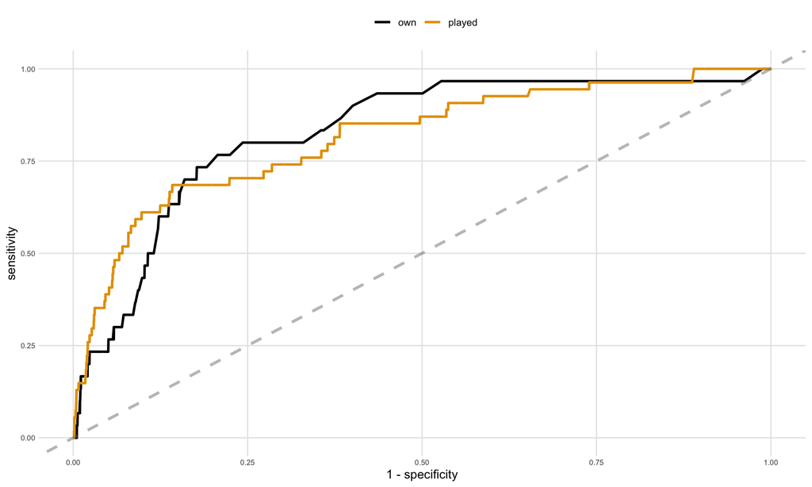

Another way to think about the model performance is to view its lift, or its ability to detect the positive outcomes over that of a null model. High lift indicates the model can much more quickly find all of the positive outcomes (in this case, games owned or played by the user), while a model with no lift is no better than random guessing.

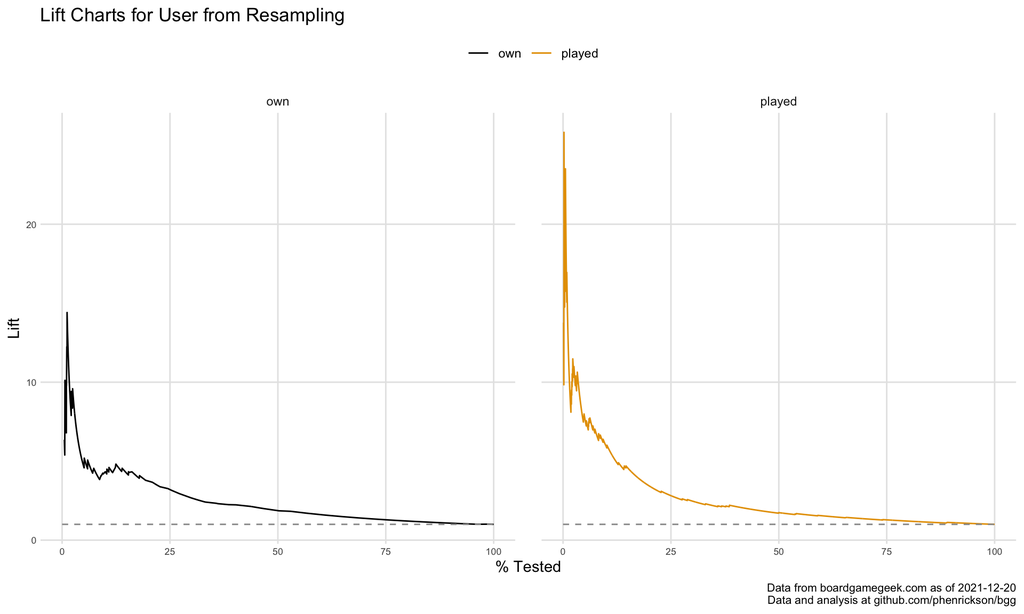

## 3.3 Most and Least Likely Games

What games does the model think thechampz is **most likely to own** that are **not** in their collection?

| username | yearpublished | game_id | name | pred_own | actual_own |
| --- | --- | --- | --- | --- | --- |
| thechampz | 2018 | 244711 | Newton | 0.28 | 0 |
| thechampz | 2009 | 39683 | At the Gates of Loyang | 0.18 | 0 |
| thechampz | 2014 | 156129 | Deception: Murder in Hong Kong | 0.18 | 0 |
| thechampz | 2008 | 37111 | Battlestar Galactica: The Board Game | 0.16 | 0 |
| thechampz | 2007 | 31260 | Agricola | 0.16 | 0 |

What games does the model think thechampz is **least likely to own** that **are** in their collection?

| username | yearpublished | game_id | name | pred_own | actual_own |
| --- | --- | --- | --- | --- | --- |
| thechampz | 2019 | 282493 | TINYforming Mars | 0 | 1 |
| thechampz | 2010 | 87890 | Prêt-à-Porter | 0 | 1 |
| thechampz | 2011 | 97207 | Dungeon Petz | 0 | 1 |
| thechampz | 2018 | 245638 | Coimbra | 0 | 1 |
| thechampz | 2018 | 262215 | Blackout: Hong Kong | 0 | 1 |

## 3.4 Top Games by Year

Top 25 games most likely to be owned by the user in each year, highlighting in blue the games that the user has owned/played.

| rank | 2011 | 2012 | 2013 | 2014 | 2015 | 2016 | 2017 | 2018 | 2019 |
| --- | --- | --- | --- | --- | --- | --- | --- | --- | --- |
| 1 | Discworld: Ankh-Morpork | Suburbia | Caverna: The Cave Farmers | Deception: Murder in Hong Kong | Grand Austria Hotel | Timebomb | Clans of Caledonia | Newton | Nanty Narking |
| 2 | The Gnomes of Zavandor | Milestones | Bremerhaven | Ultimate Werewolf | A Study in Emerald (Second Edition) | The Colonists | Riverboat | Reykholt | Mandala |
| 3 | Pergamon: Second Edition | The Resistance: Avalon | Mascarade | One Night Ultimate Werewolf | One Night Revolution | Lorenzo il Magnifico | Tortuga 1667 | Nemesis | Maracaibo |
| 4 | PAX | Siberia: The Card Game | Citrus | Grog Island | I, Spy | New Angeles | Gloomhaven | Patchwork Express | Subtext |
| 5 | Feudality | One Night Werewolf | Händler der Karibik | [redacted] | One Night Ultimate Vampire | Secret Hitler | One Night Ultimate Alien | Gingerbread House | DANY |
| 6 | The City | War of the Ring: Second Edition | Bomb Squad | Legendary Encounters: An Alien Deck Building Game | Trambahn | Touria | The Cousins' War | Hail Hydra | Age of Dirt: A Game of Uncivilization |
| 7 | Sekigahara: The Unification of Japan | Würfelwurst | Palmyra | Templar Intrigue | Oh My Goods! | Agricola: Family Edition | Valletta | Werewords Deluxe Edition | Watergate |
| 8 | Drako: Dragon & Dwarves | Keyflower | Smash Up: Awesome Level 9000 | Patchwork | Isle of Skye: From Chieftain to King | Port Royal: Unterwegs! | Bärenpark | NEOM | Foothills |
| 9 | Principato | A Fake Artist Goes to New York | Hanamikoji | Five Tribes | ...and then, we held hands. | Agricola (Revised Edition) | Tybor the Builder | Fuji | Paris: La Cité de la Lumière |
| 10 | Gears of War: The Board Game | Snowdonia | Cruel Necessity: The English Civil Wars 1640-1653 | Murano | Hengist | Terraforming Mars | Noria | Piepmatz | The Magnificent |
| 11 | Ora et Labora | Mage Wars Arena | Pathfinder Adventure Card Game: Rise of the Runelords – Base Set | Gold Ahoy! | The Pursuit of Happiness | Fight for Olympus | Santo Domingo | Muse: Awakenings | Orléans Stories |
| 12 | Space Empires: 4X | Targi | City of Remnants | Sons of Anarchy: Men of Mayhem | Mombasa | Guilds of London | Altiplano | Rising Sun | Masters of Renaissance: Lorenzo il Magnifico – The Card Game |
| 13 | Santiago de Cuba | Neuroshima: Convoy | The Witches: A Discworld Game | Johari | 504 | Inis | Pulsar 2849 | Too Many Bones: Undertow | Amul |
| 14 | Pastiche | Agricola: All Creatures Big and Small | Theseus: The Dark Orbit | Orléans | Texas Showdown | Beyond Baker Street | Pendragon: The Fall of Roman Britain | Smash Up: That '70s Expansion | Obscurio |
| 15 | Walnut Grove | Le Havre: The Inland Port | Eight-Minute Empire: Legends | Spyfall | Die Legenden von Andor: Chada & Thorn | Insider | Montana | Duelosaur Island | The Grimm Masquerade |
| 16 | Siberia | Polis: Fight for the Hegemony | Legacy: The Testament of Duke de Crecy | Secret Moon | Sylvion | The Oregon Trail Card Game | Magic Maze | Kero | Nevsky: Teutons and Rus in Collision 1240-1242 |
| 17 | Mage Knight Board Game | Tzolk'in: The Mayan Calendar | Prosperity | Heroes of Normandie | Daxu | When I Dream | Aristeia! | The Cousins' War (Second Edition) | Hearts and Minds: Vietnam 1965-1975 (Third Edition) |
| 18 | Eminent Domain | Legends of Andor | Tash-Kalar: Arena of Legends | The Battle of Five Armies | Raptor | The Networks | LYNGK | Blossoms | Blitzkrieg!: World War Two in 20 Minutes |
| 19 | Takenoko | Spartacus: A Game of Blood and Treachery | Train Heist | Smash Up: Monster Smash | Star Realms: Colony Wars | Costa Rica | Smash Up: Big in Japan | Orchard: A 9 card solitaire game | Spire's End |
| 20 | My Happy Farm | Wiz-War (Eighth Edition) | Madeira | Fields of Arle | Spirits of the Rice Paddy | Bohemian Villages | Smash Up: What Were We Thinking? | The Order of Vampire Hunters | Unmatched: Robin Hood vs. Bigfoot |
| 21 | Kingdom Builder | Goblins, Inc. | Firefly: The Game | Star Realms | Haspelknecht | Smash Up: It's Your Fault! | Caverna: Cave vs Cave | The Edge: Dawnfall | Batman: Gotham City Chronicles |
| 22 | Vintage | Il Vecchio | Castle Dice | The Ancient World | Blood Rage | 13 Days: The Cuban Missile Crisis | Codenames: Duet | Dice Hospital | Black Rose Wars |
| 23 | Tragedy Looper | OddVille | 8 Masters' Revenge | Imperial Settlers | Burgle Bros. | Bohnanza: The Duel | Fog of Love | Root | Sabotage |
| 24 | Monster Trap | Clash of Cultures | UGO! | Castles of Mad King Ludwig | My Village | Exceed Fighting System | Mythic Battles: Pantheon | Exit: The Game – The Mysterious Museum | Freshwater Fly |
| 25 | Eclipse | Smash Up | The Great Heartland Hauling Co. | DungeonQuest Revised Edition | Above and Below | Star Trek: The Dice Game | First Martians: Adventures on the Red Planet | Gen7: A Crossroads Game | Circadians: First Light |

## 3.5 Interactive Predictions from Resampling

Interactive table for predictions from resampling.

|  | username | yearpublished | rank | game_id | name | pred_played | pred_own | actual_played | actual_own |
| --- | --- | --- | --- | --- | --- | --- | --- | --- | --- |
| 1 | thechampz | 1900 | 84 | 9364 | Doppelkopf | 0.02 | 0.03 | 0 | 0 |
| 2 | thechampz | 1900 | 653 | 11670 | The Game of Authors | 0.11 | 0.01 | 0 | 0 |
| 3 | thechampz | 1900 | 655 | 10799 | Old Maid | 0.06 | 0.01 | 0 | 0 |
| 4 | thechampz | 1900 | 789 | 5546 | Marbles | 0 | 0 | 0 | 0 |
| 5 | thechampz | 1900 | 792 | 11901 | Tic-Tac-Toe | 0.01 | 0 | 0 | 0 |
| 6 | thechampz | 1900 | 837 | 188 | Go | 0 | 0 | 0 | 0 |
| 7 | thechampz | 1900 | 938 | 171 | Chess | 0 | 0 | 0 | 0 |
| 8 | thechampz | 1900 | 946 | 2065 | Shogi | 0.01 | 0 | 0 | 0 |
| 9 | thechampz | 1900 | 948 | 2393 | Xiangqi | 0 | 0 | 0 | 0 |
| 10 | thechampz | 1900 | 1164 | 26952 | International Checkers | 0 | 0 | 0 | 0 |

[output cut: 7426 more lines]

# 4 Validating the Model on 2020

How well did a model trained on a user’s collection through 2019 perform in predicting games for the user from 2020?

| username | outcome_type | yearpublished | .metric | .estimator | .estimate |
| --- | --- | --- | --- | --- | --- |
| thechampz | own | 2020 | roc_auc | binary | 0.665 |
| thechampz | played | 2020 | roc_auc | binary | 0.887 |

Table of top 25 games from 2020, highlighting games that the user owns.

| username | yearpublished | game_id | name | pred_own | pred_played | actual_own | actual_played |
| --- | --- | --- | --- | --- | --- | --- | --- |
| thechampz | 2020 | 292333 | Cowboys II: Cowboys & Indians Edition | 0.15 | 0.11 | 0 | 0 |
| thechampz | 2020 | 300322 | Hallertau | 0.10 | 0.25 | 0 | 0 |
| thechampz | 2020 | 323784 | Ghost Letters | 0.07 | 0.18 | 0 | 0 |
| thechampz | 2020 | 291457 | Gloomhaven: Jaws of the Lion | 0.04 | 0.39 | 1 | 1 |
| thechampz | 2020 | 301032 | The March of Progress | 0.04 | 0.04 | 0 | 0 |
| thechampz | 2020 | 315954 | Hunt A Killer: Death at the Dive Bar | 0.04 | 0.03 | 0 | 0 |
| thechampz | 2020 | 325555 | Cantaloop: Book 1 – Breaking into Prison | 0.04 | 0.05 | 0 | 0 |
| thechampz | 2020 | 261403 | Inhuman Conditions | 0.03 | 0.04 | 0 | 0 |
| thechampz | 2020 | 263421 | Enigma: Beyond Code | 0.03 | 0.07 | 0 | 0 |
| thechampz | 2020 | 301030 | The Ming Voyages | 0.03 | 0.02 | 0 | 0 |
| thechampz | 2020 | 301716 | Glasgow | 0.03 | 0.08 | 0 | 0 |
| thechampz | 2020 | 307997 | Insider Black | 0.03 | 0.03 | 0 | 0 |
| thechampz | 2020 | 312762 | The Joker | 0.03 | 0.04 | 0 | 0 |
| thechampz | 2020 | 313817 | Hello Neighbor: The Secret Neighbor Party Game | 0.03 | 0.04 | 0 | 0 |
| thechampz | 2020 | 184267 | On Mars | 0.02 | 0.14 | 0 | 0 |
| thechampz | 2020 | 256317 | Guild Master | 0.02 | 0.10 | 0 | 0 |
| thechampz | 2020 | 269847 | Dracula's Feast: New Blood | 0.02 | 0.02 | 0 | 0 |
| thechampz | 2020 | 298261 | Mekhane | 0.02 | 0.02 | 0 | 0 |
| thechampz | 2020 | 302465 | Obsidia | 0.02 | 0.01 | 0 | 0 |
| thechampz | 2020 | 194517 | Super Fantasy Brawl | 0.01 | 0.01 | 0 | 0 |
| thechampz | 2020 | 207486 | Infinities: Defiance of Fate | 0.01 | 0.00 | 0 | 0 |
| thechampz | 2020 | 227224 | The Red Cathedral | 0.01 | 0.01 | 0 | 0 |
| thechampz | 2020 | 228602 | Valor & Villainy: Minions of Mordak | 0.01 | 0.00 | 0 | 0 |
| thechampz | 2020 | 229782 | Roland Wright: The Dice Game | 0.01 | 0.01 | 0 | 0 |
| thechampz | 2020 | 236713 | Sea of Plunder | 0.01 | 0.01 | 0 | 0 |

# 5 Predicting Upcoming Games (2020 and On) for **thechampz**

Examine the top games for the test set.

| username | yearpublished | game_id | name | rank | own | played |
| --- | --- | --- | --- | --- | --- | --- |
| thechampz | 2020 | 292333 | Cowboys II: Cowboys & Indians Edition | 1 | 0.15 | 0.11 |
| thechampz | 2020 | 300322 | Hallertau | 2 | 0.10 | 0.25 |
| thechampz | 2020 | 323784 | Ghost Letters | 3 | 0.07 | 0.18 |
| thechampz | 2020 | 325555 | Cantaloop: Book 1 – Breaking into Prison | 4 | 0.04 | 0.05 |
| thechampz | 2020 | 315954 | Hunt A Killer: Death at the Dive Bar | 5 | 0.04 | 0.03 |
| thechampz | 2020 | 301032 | The March of Progress | 6 | 0.04 | 0.04 |
| thechampz | 2020 | 291457 | Gloomhaven: Jaws of the Lion | 7 | 0.04 | 0.39 |
| thechampz | 2020 | 301030 | The Ming Voyages | 8 | 0.03 | 0.02 |
| thechampz | 2020 | 301716 | Glasgow | 9 | 0.03 | 0.08 |
| thechampz | 2020 | 263421 | Enigma: Beyond Code | 10 | 0.03 | 0.07 |
| thechampz | 2020 | 307997 | Insider Black | 11 | 0.03 | 0.03 |
| thechampz | 2020 | 261403 | Inhuman Conditions | 12 | 0.03 | 0.04 |
| thechampz | 2020 | 312762 | The Joker | 13 | 0.03 | 0.04 |
| thechampz | 2020 | 313817 | Hello Neighbor: The Secret Neighbor Party Game | 14 | 0.03 | 0.04 |
| thechampz | 2020 | 302465 | Obsidia | 15 | 0.02 | 0.01 |
| thechampz | 2020 | 256317 | Guild Master | 16 | 0.02 | 0.10 |
| thechampz | 2020 | 269847 | Dracula's Feast: New Blood | 17 | 0.02 | 0.02 |
| thechampz | 2020 | 298261 | Mekhane | 18 | 0.02 | 0.02 |
| thechampz | 2020 | 184267 | On Mars | 19 | 0.02 | 0.14 |
| thechampz | 2020 | 277927 | Bites | 20 | 0.01 | 0.02 |
| thechampz | 2020 | 311193 | Anno 1800 | 21 | 0.01 | 0.02 |
| thechampz | 2020 | 316857 | Plantopia: The Card Game | 22 | 0.01 | 0.02 |
| thechampz | 2020 | 194517 | Super Fantasy Brawl | 23 | 0.01 | 0.01 |
| thechampz | 2020 | 207486 | Infinities: Defiance of Fate | 24 | 0.01 | 0.00 |
| thechampz | 2020 | 248125 | Monumental | 25 | 0.01 | 0.01 |
| thechampz | 2021 | 343905 | Boonlake | 1 | 0.14 | 0.52 |
| thechampz | 2021 | 291847 | Mantis Falls | 2 | 0.09 | 0.09 |
| thechampz | 2021 | 316287 | Quest | 3 | 0.05 | 0.19 |
| thechampz | 2021 | 283387 | Rocketmen | 4 | 0.04 | 0.07 |
| thechampz | 2021 | 308989 | Bristol 1350 | 5 | 0.04 | 0.04 |
| thechampz | 2021 | 310100 | Nemesis: Lockdown | 6 | 0.04 | 0.03 |
| thechampz | 2021 | 314393 | Wutaki | 7 | 0.04 | 0.06 |
| thechampz | 2021 | 330038 | Llamaland | 8 | 0.03 | 0.04 |
| thechampz | 2021 | 298102 | Roll Camera!: The Filmmaking Board Game | 9 | 0.03 | 0.30 |
| thechampz | 2021 | 337262 | Fangs | 10 | 0.03 | 0.03 |
| thechampz | 2021 | 298378 | Maharaja | 11 | 0.03 | 0.03 |
| thechampz | 2021 | 313262 | Shamans | 12 | 0.03 | 0.09 |
| thechampz | 2021 | 340466 | Unfathomable | 13 | 0.03 | 0.14 |
| thechampz | 2021 | 310873 | Carnegie | 14 | 0.02 | 0.08 |
| thechampz | 2021 | 295293 | The Thing: The Boardgame | 15 | 0.02 | 0.03 |
| thechampz | 2021 | 306321 | Night of the Ninja | 16 | 0.02 | 0.03 |
| thechampz | 2021 | 323317 | Mouse Cheese Cat Cucumber | 17 | 0.02 | 0.03 |
| thechampz | 2021 | 337389 | Snakesss | 18 | 0.02 | 0.05 |
| thechampz | 2021 | 330036 | Great Plains | 19 | 0.02 | 0.01 |
| thechampz | 2021 | 291845 | Three Sisters | 20 | 0.01 | 0.01 |
| thechampz | 2021 | 312618 | Flourish | 21 | 0.01 | 0.01 |
| thechampz | 2021 | 325022 | Coffee Traders | 22 | 0.01 | 0.01 |
| thechampz | 2021 | 329873 | GROVE: A 9 card solitaire game | 23 | 0.01 | 0.01 |
| thechampz | 2021 | 337195 | Growing Season | 24 | 0.01 | 0.01 |
| thechampz | 2021 | 239175 | Shiver Me Timbers | 25 | 0.01 | 0.01 |
| thechampz | 2022 | 283137 | Human Punishment: The Beginning | 1 | 0.07 | 0.24 |
| thechampz | 2022 | 295770 | Frosthaven | 2 | 0.04 | 0.09 |
| thechampz | 2022 | 271601 | Feed the Kraken | 3 | 0.04 | 0.04 |
| thechampz | 2022 | 240980 | Blood on the Clocktower | 4 | 0.03 | 0.03 |
| thechampz | 2022 | 316624 | Stationfall | 5 | 0.03 | 0.04 |
| thechampz | 2022 | 320718 | Hidden Leaders | 6 | 0.03 | 0.09 |
| thechampz | 2022 | 317511 | Tindaya | 7 | 0.02 | 0.01 |
| thechampz | 2022 | 311988 | Frostpunk: The Board Game | 8 | 0.01 | 0.01 |
| thechampz | 2022 | 252315 | The Everrain | 9 | 0.01 | 0.00 |
| thechampz | 2022 | 277025 | Vampire: The Masquerade – CHAPTERS | 10 | 0.01 | 0.01 |
| thechampz | 2022 | 299594 | Megapulse | 11 | 0.01 | 0.00 |
| thechampz | 2022 | 316915 | U.S.S. Freedom | 12 | 0.01 | 0.01 |
| thechampz | 2022 | 330950 | Age of Galaxy | 13 | 0.01 | 0.01 |
| thechampz | 2022 | 348463 | ECO: Coral Reef | 14 | 0.01 | 0.01 |
| thechampz | 2022 | 305096 | Endless Winter: Paleoamericans | 15 | 0.01 | 0.01 |
| thechampz | 2022 | 274471 | Malhya: Lands of Legends | 16 | 0.01 | 0.00 |
| thechampz | 2022 | 294880 | Chai: Tea for 2 | 17 | 0.01 | 0.01 |
| thechampz | 2022 | 319807 | Shogun no Katana | 18 | 0.01 | 0.02 |
| thechampz | 2022 | 281258 | Sub Terra II: Inferno's Edge | 19 | 0.01 | 0.00 |
| thechampz | 2022 | 311823 | Nova Aetas Renaissance | 20 | 0.01 | 0.00 |
| thechampz | 2022 | 312959 | Rallyman: DIRT | 21 | 0.01 | 0.00 |
| thechampz | 2022 | 280726 | Legacies | 22 | 0.01 | 0.02 |
| thechampz | 2022 | 299106 | Fractal: Beyond the Void | 23 | 0.01 | 0.01 |
| thechampz | 2022 | 340325 | Vagrantsong | 24 | 0.01 | 0.01 |
| thechampz | 2022 | 256680 | Return to Dark Tower | 25 | 0.01 | 0.01 |

## 5.1 Interactive Table for Upcoming Games 2020 and On

|  | username | yearpublished | game_id | name | rank | own | played |
| --- | --- | --- | --- | --- | --- | --- | --- |
| 1 | thechampz | 2020 | 292333 | Cowboys II: Cowboys &amp; Indians Edition | 1 | 0.15 | 0.11 |
| 2 | thechampz | 2021 | 343905 | Boonlake | 2 | 0.14 | 0.52 |
| 3 | thechampz | 2020 | 300322 | Hallertau | 3 | 0.1 | 0.25 |
| 4 | thechampz | 2021 | 291847 | Mantis Falls | 4 | 0.09 | 0.09 |
| 5 | thechampz | 2022 | 283137 | Human Punishment: The Beginning | 5 | 0.07 | 0.24 |
| 6 | thechampz | 2020 | 323784 | Ghost Letters | 6 | 0.07 | 0.18 |
| 7 | thechampz | 2021 | 316287 | Quest | 7 | 0.05 | 0.19 |
| 8 | thechampz | 2020 | 325555 | Cantaloop: Book 1 – Breaking into Prison | 8 | 0.04 | 0.05 |
| 9 | thechampz | 2022 | 295770 | Frosthaven | 9 | 0.04 | 0.09 |
| 10 | thechampz | 2020 | 315954 | Hunt A Killer: Death at the Dive Bar | 10 | 0.04 | 0.03 |

[output cut: 1627 more lines]